# R Notebook

CCA con VEGAN

```r
setwd("~/Dropbox/maestría")
practicas1<-read.table("CCAManejo.csv", sep=",", header=TRUE)
familias1<-read.table("CCAfamilias.csv", sep=",", header=TRUE)
practicas <- practicas1[, 3:24]
familias <- familias1[, 2:26]
```

```r
#fijándome sólo en las más abundantes de los guilds herbivoros, depredadres, polifagos y detritivoros(sapro), o sea, quito todo menos Chrysomelidae, Curculionidae, Coccinellidae, Cleridae, Carabidae, Anthicidae, Phalacridae, Nitidulidae, Aderidae
abundance.matrix=subset(familias, select=c(Chrysomellidae, Curculionidae, Coccinellidae, Cleridae, Carabidae, Nitidullidae, Anobiidae, Cantharidae, Phalacridae))
abundance.matrix
```

|  | Chrysomellidae | Curculionidae | Coccinellidae | Cleridae | Carabidae | Nitidullidae | Anobiidae | Cantharidae | Phalacridae |
| --- | --- | --- | --- | --- | --- | --- | --- | --- | --- |
| 1 | 69 | 2 | 0 | 17 | 0 | 1 | 1 | 5 | 0 |
| 2 | 15 | 3 | 0 | 0 | 0 | 0 | 0 | 0 | 4 |
| 3 | 26 | 0 | 0 | 2 | 0 | 1 | 1 | 2 | 2 |
| 4 | 26 | 2 | 2 | 1 | 0 | 0 | 0 | 4 | 0 |
| 5 | 34 | 0 | 5 | 0 | 4 | 0 | 0 | 6 | 0 |
| 6 | 5 | 0 | 0 | 1 | 0 | 0 | 2 | 1 | 1 |
| 7 | 130 | 1 | 2 | 0 | 1 | 0 | 0 | 3 | 2 |
| 8 | 47 | 0 | 0 | 0 | 1 | 0 | 0 | 28 | 1 |
| 9 | 16 | 0 | 8 | 2 | 0 | 1 | 1 | 6 | 6 |
| 10 | 1 | 0 | 0 | 0 | 0 | 0 | 0 | 0 | 0 |

[output cut: 6 more lines]

```r
abundance.matrix<-data.matrix(abundance.matrix) #lo hago matriz
```

```r
#implement a square root transformation to dampen the influence of large counts on the results
abundance.matrix2 <- sqrt(abundance.matrix)
abundance.matrix2
```

```
   Chrysomellidae Curculionidae Coccinellidae Cleridae Carabidae Nitidullidae Anobiidae Cantharidae Phalacridae
1        8.306624      1.414214      0.000000 4.123106         0            1  1.000000    2.236068    0.000000
2        3.872983      1.732051      0.000000 0.000000         0            0  0.000000    0.000000    2.000000
3        5.099020      0.000000      0.000000 1.414214         0            1  1.000000    1.414214    1.414214
4        5.099020      1.414214      1.414214 1.000000         0            0  0.000000    2.000000    0.000000
5        5.830952      0.000000      2.236068 0.000000         2            0  0.000000    2.449490    0.000000
6        2.236068      0.000000      0.000000 1.000000         0            0  1.414214    1.000000    1.000000
7       11.401754      1.000000      1.414214 0.000000         1            0  0.000000    1.732051    1.414214
8        6.855655      0.000000      0.000000 0.000000         1            0  0.000000    5.291503    1.000000
9        4.000000      0.000000      2.828427 1.414214         0            1  1.000000    2.449490    2.449490
10       1.000000      0.000000      0.000000 0.000000         0            0  0.000000    0.000000    0.000000
11       6.164414      7.000000      2.000000 1.000000         1            1  0.000000    1.732051    0.000000
12       6.557439      2.236068      1.414214 0.000000         1            2  0.000000    5.000000    2.828427
13      16.852300      1.000000      1.000000 1.000000         0            0  1.000000    3.464102    0.000000
14       4.898979      1.414214      0.000000 1.414214         0            0  0.000000    2.000000    1.000000
15       5.099020      1.000000      0.000000 1.000000         0            1  0.000000    4.358899    0.000000
16       2.449490      0.000000      0.000000 0.000000         0            0  0.000000    4.582576    0.000000
```

First, we will apply correspondence analysis (CA) to the beetle abundance matrix and visualize the major axes of variation in beetle community composition. Next, we will perform a constrained CA, also known as canonical CA (CCA), bringing the management data into play as predictors of beetle community composition.

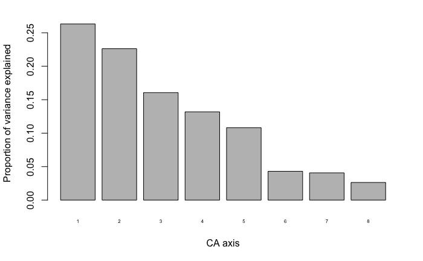

```r
my.ca <- cca(abundance.matrix2)
barplot(my.ca$CA$eig/my.ca$tot.chi, names.arg = 1:my.ca$CA$rank, cex.names = 0.5, ylab="Proportion of variance explained", xlab="CA axis")
```

```r
# CA proportions of variance explained
head(my.ca$CA$eig/my.ca$CA$tot.chi)
```

```
       CA1        CA2        CA3        CA4        CA5        CA6
0.26313849 0.22620947 0.16056138 0.13186241 0.10819360 0.04299102
```

The fact that the first 2 axes explain a combined ~50% of variation in the data indicates that beetle community composition is not easily reduced to just one or two axes of variation. Let’s look at a scatterplot of our data with respect to the first two CAs:

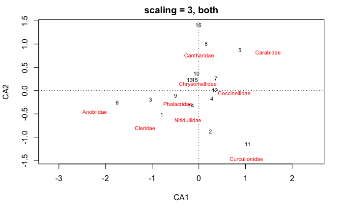

```r
plot(my.ca, scaling="symmetric", main="scaling = 3, both")
```

```r
#text(my.ca,  labels= practicas1$manejo)
```

An alternative way to make more space on our plot is to simply display the sites and species on separate plots. Let’s also label sites to represent our typology, and increase the size of the labels.

```r
# 2 panels
layout(matrix(1:2,1,2))

# plot sites
plot(my.ca, display="sites", type="n", main="Sites", scaling="sites")
text(my.ca, display="sites", labels= practicas1$manejo,scaling="sites")
```

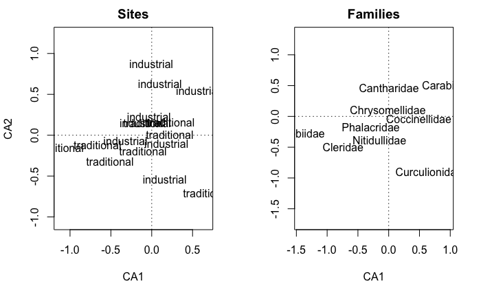

```r
# plot species
plot(my.ca, display="species", type="n", ylab="", main="Families", scaling="species")
text(my.ca, display="species", col="black", scaling="species")
```

That’s better. The labels help reveal that the second CA axis reflects a management gradient, suggesting that management is an important factor structuring beetle community composition (though not the most important one, as it is the second and not the first axis that reflects this).

With the sites and species separated out, it is easier to see the differentiation among species as well. Given that CA2 appears to be an industrial-traditional gradient, we can see that some beetle species tend to be found in the traditional plots (e.g. Curculionidae, Nitidulidae, Cleridae), while others tend to be found in the industrialized ones (e.g. Carabidae). Species near the center of the graph do not show much differentiation among either regions or habitats.

Now we will bring in the management variables. Let’s make a subset of the data for the managemebt variables by substracting those who are too correlated >70% (number of varieties and monoculture, leving number of crops; fallow period leaving irrigation) and also those that contributed very scarcely to both PCA components 1 and 2 (stubble, comercial.agriculture, manure, subsistence.agriculture, organic.fertilizer, native.seeds, green.manure) - these will be our predictor variables:

```r
# predictor variables
fixed=subset(practicas, select=-c(number.varieties, monoculture, fallow.period, stubble, comercial.agr, manure, subsistence.agr, organic.fertilizer, native.seeds, green.manure))
```

Run the CCA and compute variance inflation factors (VIF) to check for redundancy in the predictor variables. As a rule of thumb, VIF > 10 indicates problematic levels of redundancy. Redundant predictor variables do not adversely effect model fit, but it does make it difficult to interpret the estimated effects of individual predictor variables.

```r
# the formula notation y ~ . means that all variables in 'fixed' should be included
my.cca <- cca(abundance.matrix2 ~ ., data=fixed)

# VIFs
vif.cca(my.cca)
```

```
         number.crops              rotation       animal.traction            irrigation              quelites
            45.496893              2.273379              4.555076             11.352545             10.885182
       managed.border                 trees               compost industrial.fertilizer  industrial.pesticide
            14.532086              9.424924             42.579484             10.779473              7.275042
 industrial.herbicide     organic.pesticide
             5.545551             18.715777
```

It seems we have some problematic redundancy in our predictor variables. A principled way to choose which variable(s) to drop is to use the drop1 function, which compares the change in AIC the results from dropping each variable from the full model:

```r
drop1(my.cca, test="perm")
```

```
                      Df    AIC      F Pr(>F)
<none>                   25.050
number.crops           1 32.196 2.3135  0.075 .
rotation               1 26.779 0.7874  0.675
animal.traction        1 27.760 1.0269  0.450
irrigation             1 32.408 2.3844  0.070 .
quelites               1 32.288 2.3439  0.075 .
managed.border         1 29.165 1.3964  0.245
trees                  1 32.096 2.2802  0.075 .
compost                1 32.165 2.3032  0.080 .
industrial.fertilizer  1 31.311 2.0274  0.090 .
industrial.pesticide   1 31.102 1.9622  0.095 .
industrial.herbicide   1 32.925 2.5611  0.030 *
organic.pesticide      1 30.129 1.6694  0.195
---
Signif. codes:  0 ‘***’ 0.001 ‘**’ 0.01 ‘*’ 0.05 ‘.’ 0.1 ‘ ’ 1
```

It looks like dropping rotation would have the least negative effect on the AIC. Let’s try dropping it and refitting the CCA:

```r
# drop rotation from the fixed effects
fixed <- fixed[,-2]

# rerun the cca
my.cca <- cca(abundance.matrix2 ~ ., data=fixed)

# VIFs
vif.cca(my.cca)
```

```
         number.crops       animal.traction            irrigation              quelites        managed.border
            45.252060              4.542963             11.346973             10.835752             12.589742
                trees               compost industrial.fertilizer  industrial.pesticide  industrial.herbicide
             9.420625             41.903393             10.526568              5.980746              5.429475
    organic.pesticide
            18.688066
```

```r
drop1(my.cca, test="perm")
```

```
                      Df    AIC      F Pr(>F)
<none>                   26.779
number.crops           1 32.330 2.4124  0.025 *
animal.traction        1 28.523 1.0546  0.390
irrigation             1 32.552 2.5018  0.030 *
quelites               1 32.396 2.4389  0.035 *
managed.border         1 29.180 1.2664  0.320
trees                  1 32.265 2.3863  0.035 *
compost                1 32.439 2.4562  0.025 *
industrial.fertilizer  1 31.912 2.2467  0.050 *
industrial.pesticide   1 32.027 2.2919  0.050 *
industrial.herbicide   1 33.240 2.7875  0.010 **
organic.pesticide      1 30.671 1.7808  0.105
---
Signif. codes:  0 ‘***’ 0.001 ‘**’ 0.01 ‘*’ 0.05 ‘.’ 0.1 ‘ ’ 1
```

Now we drop animal.traction

```r
# drop quelites from the fixed effects
fixed <- fixed[,-2]

# rerun the cca
my.cca <- cca(abundance.matrix2 ~ ., data=fixed)

# VIFs
vif.cca(my.cca)
```

```
         number.crops            irrigation              quelites        managed.border                 trees
            40.253692             10.752775              8.261237              8.214599              7.984303
              compost industrial.fertilizer  industrial.pesticide  industrial.herbicide     organic.pesticide
            41.098958             10.289285              4.883910              5.409803             14.272436
```

```r
drop1(my.cca, test="perm")
```

```
                      Df    AIC      F Pr(>F)
<none>                   28.523
number.crops           1 32.570 2.2960  0.040 *
irrigation             1 33.042 2.5147  0.015 *
quelites               1 33.101 2.5422  0.040 *
managed.border         1 29.511 1.0266  0.460
trees                  1 32.946 2.4696  0.050 *
compost                1 32.821 2.4114  0.035 *
industrial.fertilizer  1 32.425 2.2305  0.035 *
industrial.pesticide   1 34.538 3.2511  0.005 **
industrial.herbicide   1 33.570 2.7666  0.020 *
organic.pesticide      1 30.934 1.5870  0.140
---
Signif. codes:  0 ‘***’ 0.001 ‘**’ 0.01 ‘*’ 0.05 ‘.’ 0.1 ‘ ’ 1
```

Now we drop managed.border

```r
# drop MixedForest from the fixed effects
fixed <- fixed[,-4]

# rerun the cca
my.cca <- cca(abundance.matrix2 ~ ., data=fixed)

# VIFs
vif.cca(my.cca)
```

```
         number.crops            irrigation              quelites                 trees               compost
            40.124741             10.575770              8.134411              7.944509             35.595509
industrial.fertilizer  industrial.pesticide  industrial.herbicide     organic.pesticide
             9.198447              4.461782              4.306253             14.265575
```

```r
drop1(my.cca, test="perm")
```

```
                      Df    AIC      F Pr(>F)
<none>                   29.511
number.crops           1 32.741 2.3194  0.030 *
irrigation             1 33.304 2.6175  0.015 *
quelites               1 33.050 2.4817  0.020 *
trees                  1 33.104 2.5106  0.025 *
compost                1 32.798 2.3494  0.025 *
industrial.fertilizer  1 32.600 2.2464  0.020 *
industrial.pesticide   1 34.906 3.5253  0.010 **
industrial.herbicide   1 33.539 2.7449  0.015 *
organic.pesticide      1 31.228 1.5688  0.135
---
Signif. codes:  0 ‘***’ 0.001 ‘**’ 0.01 ‘*’ 0.05 ‘.’ 0.1 ‘ ’ 1
```

Now we drop organic.pesticide

```r
# drop MixedForest from the fixed effects
fixed <- fixed[,-9]

# rerun the cca
my.cca <- cca(abundance.matrix2 ~ ., data=fixed)

# VIFs
vif.cca(my.cca)
```

```
         number.crops            irrigation              quelites                 trees               compost
             6.432130              5.882971              2.899264              3.575067              4.244949
industrial.fertilizer  industrial.pesticide  industrial.herbicide
             4.710523              4.190534              3.049286
```

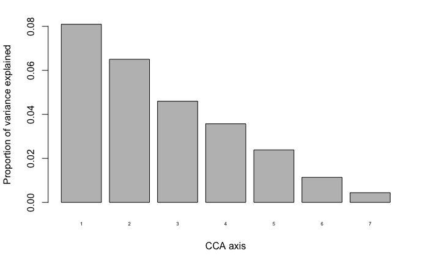

```r
barplot(my.cca$CA$eig/my.cca$tot.chi, names.arg = 1:my.cca$CA$rank, cex.names = 0.5, ylab="Proportion of variance explained", xlab="CCA axis")
```

Look at CCA plots:

```r
# 2 panels
#layout(matrix(1:2,1,2))

# plot sites
plot(my.cca, display=c("sites", "bp"), type="n", main="Sites", scaling="sites")
text(my.cca, display="sites", labels= practicas1$manejo,scaling="sites")
```

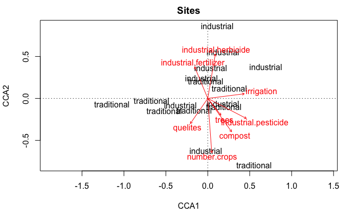

```r
text(my.cca, display="bp", col="red")
```

```r
# plot species
plot(my.cca, display=c("species", "bp"), type="n", ylab="", main="Families", scaling="species")
text(my.cca, display="species", col="black", scaling="species")
```

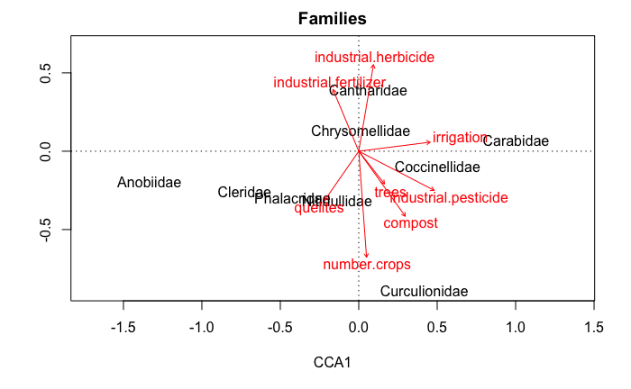

```r
text(my.cca, display="bp", col="red")
```

As in the CA, we can see the management gradient reflected along the second axis of variation (note that the direction of the gradient is arbitrary).

Curculionidae & number of crops. Cantharidae and industrial herbicide and fertilizer.

Now extract the percent of variance explained by our predictor variables and test for a significant effect of our predictor variables on beetle community composition:

```r
# proportion of variance explained
my.cca$CCA$tot.chi/my.cca$tot.chi
```

```
[1] 0.7326971
```

```r
# significance test for individual predictors (type 3 test)
anova(my.cca, by="margin")
```

```
Permutation test for cca under reduced model
Marginal effects of terms
Permutation: free
Number of permutations: 999

Model: cca(formula = abundance.matrix2 ~ number.crops + irrigation + quelites + trees + compost + industrial.fertilizer + industrial.pesticide + industrial.herbicide, data = fixed)
                      Df ChiSquare      F Pr(>F)
number.crops           1  0.063675 2.5695  0.018 *
irrigation             1  0.041702 1.6828  0.110
quelites               1  0.069605 2.8088  0.005 **
trees                  1  0.045341 1.8297  0.077 .
compost                1  0.040948 1.6524  0.145
industrial.fertilizer  1  0.064860 2.6174  0.008 **
industrial.pesticide   1  0.074673 3.0133  0.004 **
industrial.herbicide   1  0.087881 3.5464  0.001 ***
Residual               7  0.173465
---
Signif. codes:  0 ‘***’ 0.001 ‘**’ 0.01 ‘*’ 0.05 ‘.’ 0.1 ‘ ’ 1
```

```r
# significance test for entire model
anova(my.cca)
```

```
Permutation test for cca under reduced model
Permutation: free
Number of permutations: 999

Model: cca(formula = abundance.matrix2 ~ number.crops + irrigation + quelites + trees + compost + industrial.fertilizer + industrial.pesticide + industrial.herbicide, data = fixed)
         Df ChiSquare      F Pr(>F)
Model     8   0.47548 2.3984  0.001 ***
Residual  7   0.17347
---
Signif. codes:  0 ‘***’ 0.001 ‘**’ 0.01 ‘*’ 0.05 ‘.’ 0.1 ‘ ’ 1
```

FIN